# Team 3 Lab-1 Write-Up

## Chum: Regional

Looking at data:

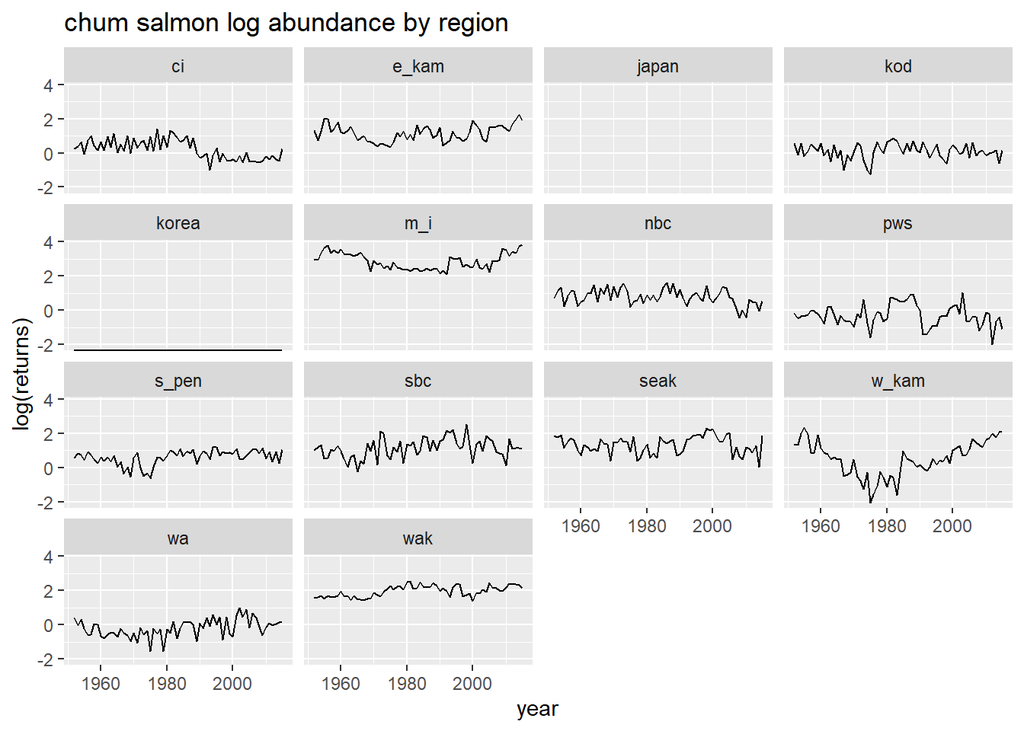

Getting a subset of the data (removing regions with no data):

```r
#removing Korea Japan because there's no data
ChumByRegion<-ruggerone_data %>%
  filter(region != "japan") %>%
  filter(region != "korea") %>%
  group_by(species, region, year) %>%
  summarize(total = sum(returns, na.rm=TRUE)) %>%
  mutate(lnreturns = log(total)) %>%
  filter(species == "chum")
head(ChumByRegion)
```

```
## # A tibble: 6 × 5
## # Groups:   species, region [1]
##   species region  year total lnreturns
##   <chr>   <chr>  <dbl> <dbl>     <dbl>
## 1 chum    ci      1952 1.25     0.226
## 2 chum    ci      1953 1.44     0.363
## 3 chum    ci      1954 1.93     0.656
## 4 chum    ci      1955 0.957   -0.0436
## 5 chum    ci      1956 2.11     0.748
## 6 chum    ci      1957 2.76     1.01
```

```r
#making sure all the regions cover all the years (or at least start and end)
ChumByRegion %>% group_by(region) %>% summarise(startyear = min(year), endyear = max(year))
```

```
## # A tibble: 12 × 3
##    region startyear endyear
##    <chr>      <dbl>   <dbl>
##  1 ci          1952    2015
##  2 e_kam       1952    2015
##  3 kod         1952    2015
##  4 m_i         1952    2015
##  5 nbc         1952    2015
##  6 pws         1952    2015
##  7 s_pen       1952    2015
##  8 sbc         1952    2015
##  9 seak        1952    2015
## 10 w_kam       1952    2015
## 11 wa          1952    2015
## 12 wak         1952    2015
```

```r
#all start in 1952 and end in 2015
```

Creating tibble to loop through:

```r
#regions vector
regions<-unique(ChumByRegion$region)
#regions key
regionskey<-c("Cook Inlet", "E. Kamchatka", "Kodiak", "Russia", "N.British Columbia",
              "Prince William Sound", "S. Alaska Pen.", "S. British Columbia", "SE Alaska", "W. Kamchatka", "Washington", "W. Alaska")
names(regionskey)<-regions #for plotting
#forecast levels
forecastlevels<-c(5, 10, 20)
#all combinations
Allcombs<-expand_grid(regions, forecastlevels)
```

Function for ACF and PACF

```r
#ACF and PACF
ACFandPACF<-function(reg){
  Chumdat<-ChumByRegion %>% filter(region == reg)
  #create time series
  datts <- ts(Chumdat$lnreturns, start=Chumdat$year[1])
  return(list(a = acf(datts, plot = FALSE), p = pacf(datts, plot = FALSE)))
}
#loop through regions/levels
DiagPlots<-lapply(regions, ACFandPACF)
names(DiagPlots)<-regions
```

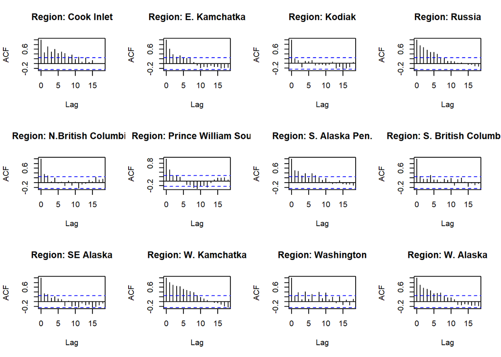

```r
#ACF plots for each region
par(mfrow=c(3,4))
for(r in 1:length(regions)){
  plot(DiagPlots[[r]][[1]], main = paste0("Region: ", regionskey[r]))
}
```

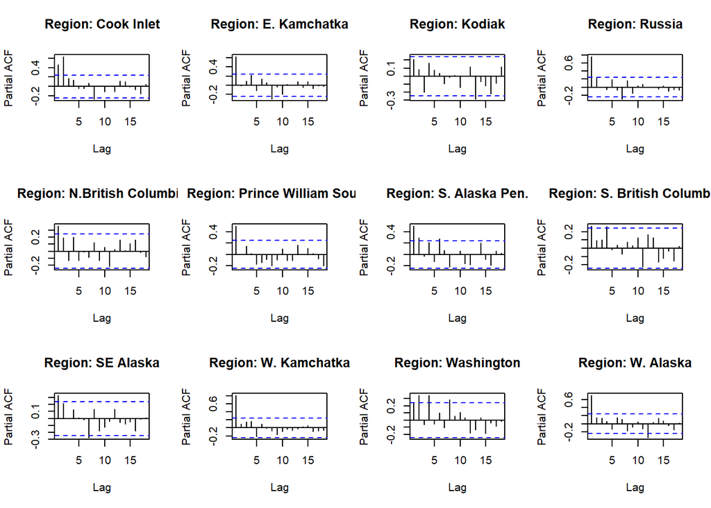

```r
#PACF plots for each region
par(mfrow=c(3,4))
for(r in 1:length(regions)){
  plot(DiagPlots[[r]][[2]], main = paste0("Region: ", regionskey[r]))
}
```

```r
#function for ARIMA models
FitModFunction<-function(reg, forelevel){
  #This function takes a region and forecast level, subsets the data according to these parameters, then sets up the time series object, and the test and train sets. It uses auto.arima to find the "best" model and then this is checked by comparing other models with DeltaAICc < 2 and the number of parameters. If auto.arima picked a the model with the lowest AIC and the fewest parameters, it forecasts using this model and checks forecast accuracy with MASE. If not, it refits the model using Arima and the simpler model, and then checks forecast accuracy with this.
  #filter region
  Chumdat<-ChumByRegion %>% filter(region == reg)
  #create time series
  datts <- ts(Chumdat$lnreturns, start=Chumdat$year[1]) #this assumes the first year in data is the start of the time series (they are in order)
  cutoff<-2015-forelevel
  train <- window(datts, 1952, cutoff)
  test <- window(datts, cutoff+1, 2015)

  mod <- auto.arima(train)

  #testing to be sure that this is the best model (is the best mode the simplest if it is within 2 AIC values?)
  trace <- capture.output({
    # assign so it doesn't pollute the output
    model <- auto.arima(datts, trace = TRUE)
  })
  con    <- textConnection(trace)
  models <- read.table(con, sep=":")
  close(con)

  #getting the "best models" that are within 2 AIC units
  BestMods<-models%>% filter(row_number() != nrow(models)) %>% mutate(AIC = replace(V2, V2 == "Inf", 99999), AIC = as.numeric(AIC), DeltaAIC = AIC-min(AIC)) %>% filter(DeltaAIC <= 2.0)
  for(i in 1:nrow(BestMods)){
    BestMods$Mod[i]<-strsplit(strsplit(strsplit(BestMods$V1[i], "[(]")[[1]][2], "[)]")[[1]][1],"[,]")
    BestMods$npar[i]<-sum(as.numeric(BestMods$Mod[i][[1]][c(1,3)]))
    if(strsplit(strsplit(BestMods$V1[i], "[(]")[[1]][2], "[)]")[[1]][2] == " with drift         "){
      BestMods$npar[i] = BestMods$npar[i] + 1
    }
  }

  New<-BestMods %>% filter(npar == min(npar))
  if(0 %in% New$DeltaAIC){
      #auto arima picked the best model
      res<-accuracy(forecast(mod, h=forelevel), test)[2,"MASE"] #test set MASE
  }else{
      #of the models with the fewest parameters, pick the lowest AIC
      newmod<-New %>% filter(AIC == min(AIC)) %>% select(Mod)
      mod<-Arima(train, order = as.numeric(strsplit(newmod$Mod[[1]], "[,]")), include.constant = TRUE)
      res<-accuracy(forecast(mod, h=forelevel), test)[2,"MASE"] #test set MASE
    }

  return(list(Fit = mod, MASE = res, Bm = BestMods)) #include best mods for testing to see that it's doing what I want
}
```

```r
RegionModsChum<-mapply(FitModFunction, Allcombs$regions, Allcombs$forecastlevels, SIMPLIFY = FALSE)
```

```r
RegionMASEChum<-sapply(RegionModsChum, function(x){y<-x$MASE})
RegionBestModChum<-sapply(RegionModsChum, function(x){y<-as.character(x$Fit)})
#combine into tables
ResultsTableChum<-Allcombs %>% add_column(Model = RegionBestModChum, MASE = RegionMASEChum)
knitr::kable(head(ResultsTableChum))
```

| regions | forecastlevels | Model | MASE |
| --- | --- | --- | --- |
| ci | 5 | ARIMA(1,1,1) | 0.4232248 |
| ci | 10 | ARIMA(1,1,1) | 0.3650863 |
| ci | 20 | ARIMA(0,0,2) with non-zero mean | 1.3678453 |
| e_kam | 5 | ARIMA(1,0,0) with non-zero mean | 2.0352335 |
| e_kam | 10 | ARIMA(1,0,0) with non-zero mean | 1.6504750 |
| e_kam | 20 | ARIMA(1,0,0) with non-zero mean | 1.4845904 |

## Pink: Combined Regions

Subset the data to look at pink salmon only.

```r
#Filter by species (Pink)
dat <- ruggerone_data %>%
  filter(species=="pink" & region=="ci") %>%
  mutate(log.returns = log(returns)) %>%
  select(year, log.returns)
```

Plot the data

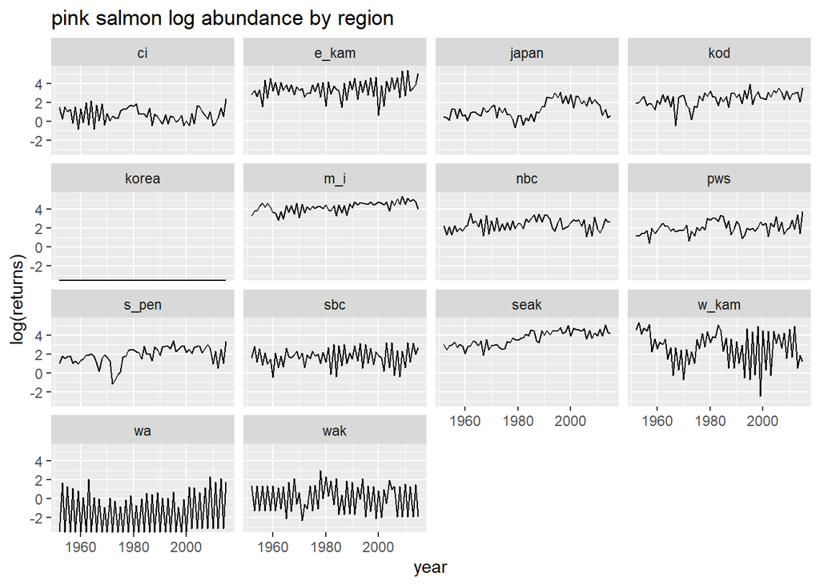

```r
#Plot by region
ruggerone_data %>%
  filter(species=="pink") %>%
  ggplot(aes(x=year, y=log(returns))) +
  geom_line() +
  ggtitle("pink salmon log abundance by region") +
  facet_wrap(~region)
```

Note that there is no data in Korea, and WA has a lot of 0 values and very low returns. We will filter these regions out. All 0 values (-Inf in log space) were removed.

```r
PinkByRegion<-ruggerone_data %>%
  filter(region != "korea") %>%
  filter(region != "wa") %>%#Remove WA too, it's trouble
  group_by(species, region, year) %>%
  summarize(total = sum(returns, na.rm=TRUE)) %>%
  mutate(lnreturns = log(total)) %>%
  mutate(lnreturns = ifelse(lnreturns == -Inf, NA, lnreturns)) %>%
  filter(species == "pink")%>%
  print(n=5)
```

```
## # A tibble: 768 × 5
## # Groups:   species, region [12]
##   species region  year total lnreturns
##   <chr>   <chr>  <dbl> <dbl>     <dbl>
## 1 pink    ci      1952  4.36     1.47
## 2 pink    ci      1953  1.30     0.264
## 3 pink    ci      1954  4.67     1.54
## 4 pink    ci      1955  2.67     0.981
## 5 pink    ci      1956  3.57     1.27
## # ℹ 763 more rows
```

Identify start and end years for each region.

```r
PinkByRegion %>% group_by(region) %>% summarise(startyear = min(year), endyear = max(year))
```

```
## # A tibble: 12 × 3
##    region startyear endyear
##    <chr>      <dbl>   <dbl>
##  1 ci          1952    2015
##  2 e_kam       1952    2015
##  3 japan       1952    2015
##  4 kod         1952    2015
##  5 m_i         1952    2015
##  6 nbc         1952    2015
##  7 pws         1952    2015
##  8 s_pen       1952    2015
##  9 sbc         1952    2015
## 10 seak        1952    2015
## 11 w_kam       1952    2015
## 12 wak         1952    2015
```

The next step is to ID Stationarity with all the pink data. Lets plot the data in aggregate.

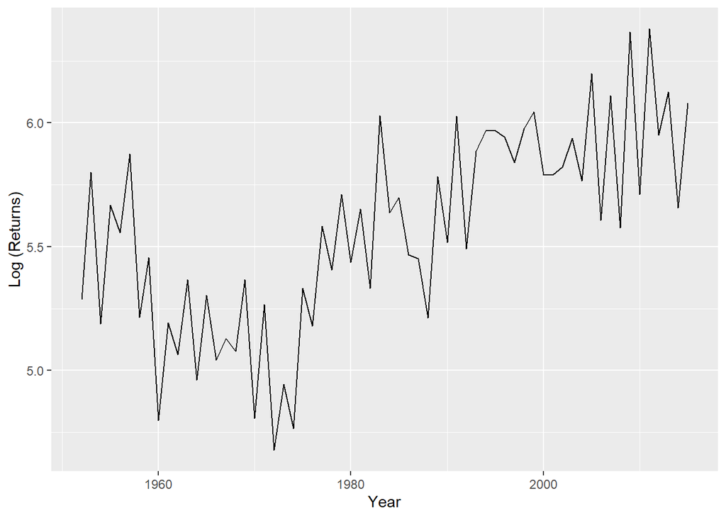

```r
PinkByRegion %>%
  group_by(year) %>%
  summarize(total = sum(total, na.rm=T)) %>%
  ggplot(aes(x=year, y=log(total))) +
  geom_line() +
  ylab('Log (Returns)') +
  xlab('Year')
```

Next, a time series object was created and we look at the ACF and PACF

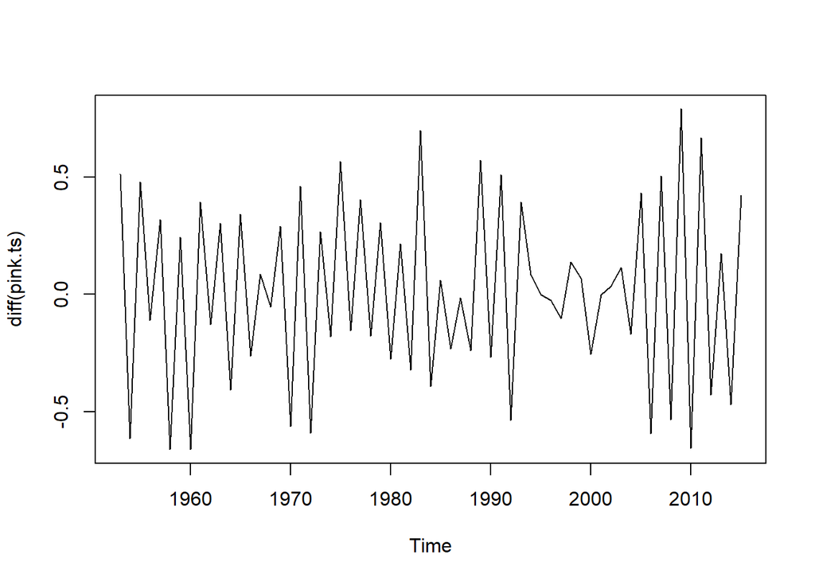

```r
total.pink<-PinkByRegion %>%
  group_by(year) %>%
  summarize(lntotal=log(sum(total, na.rm=T)))

pink.ts<-ts(total.pink$lntotal,
            start=total.pink$year[1])
plot(diff(pink.ts)) #something odd happened between 1990 and 2005
```

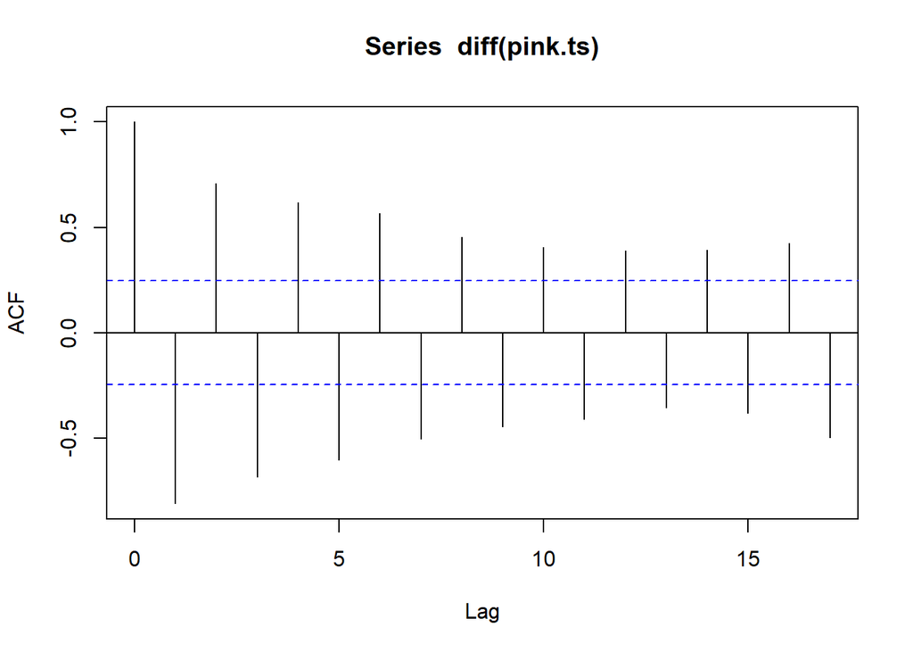

```r
acf(diff(pink.ts)) #ruh roh, ACF correlation for entire series
```

The ACF looks like there is a lot of corelation, that’s probably because Pinks have a very consistent two year cycle.

Let’s try a forecast model to see what happens.

```r
#Let's train and test with a 10 year period
train.pink<-window(pink.ts, start=1952, end=2005)
test.pink<-window(pink.ts, start=2006, end=2015)

fit <- forecast::auto.arima(train.pink, trace=T)
```

```
##
##  ARIMA(2,1,2) with drift         : Inf
##  ARIMA(0,1,0) with drift         : 44.48651
##  ARIMA(1,1,0) with drift         : -0.8966894
##  ARIMA(0,1,1) with drift         : 18.15923
##  ARIMA(0,1,0)                    : 42.45004
##  ARIMA(2,1,0) with drift         : -1.222687
##  ARIMA(3,1,0) with drift         : -2.155628
##  ARIMA(4,1,0) with drift         : 0.3831016
##  ARIMA(3,1,1) with drift         : 0.2902468
##  ARIMA(2,1,1) with drift         : Inf
##  ARIMA(4,1,1) with drift         : Inf
##  ARIMA(3,1,0)                    : -4.270823
##  ARIMA(2,1,0)                    : -3.360303
##  ARIMA(4,1,0)                    : -1.841485
##  ARIMA(3,1,1)                    : -1.889482
##  ARIMA(2,1,1)                    : Inf
##  ARIMA(4,1,1)                    : 0.4019518
##
##  Best model: ARIMA(3,1,0)
```

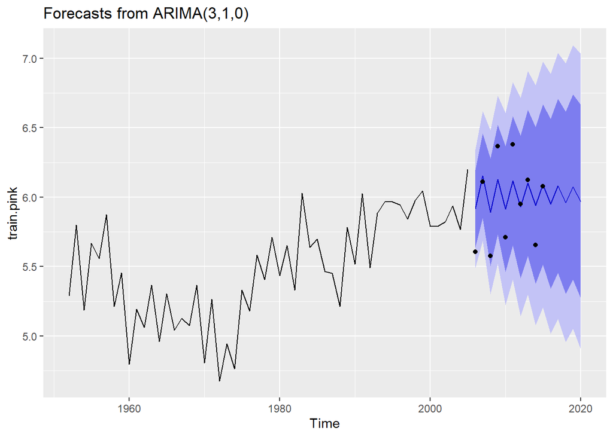

```r
fit.final.pink<-forecast::auto.arima(train.pink, approximation = F, stepwise = F)

#30 year forcast, not so believeable
fit.final.pink %>%
  forecast(h=15) %>%
  autoplot() + geom_point(aes(x=x, y=y), data=fortify(test.pink))
```

The best model was the ARIMA(3,1,0), but the forecast doesn’t look particularly great.

Given the life history of pink salmon, let’s parse the data set into two pieces, even and odd years.

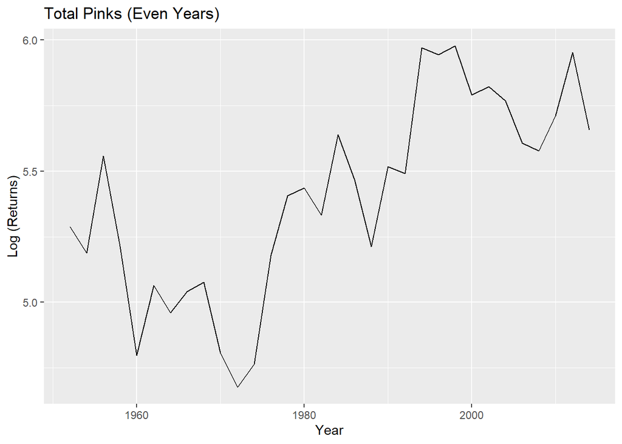

```r
#Even Years: Totals
PinkByRegion_even<-PinkByRegion %>%
  filter(year %% 2 == 0)

#Odd Years: Totals
PinkByRegion_odd<-PinkByRegion %>%
  filter(year %% 2 == 1)

#Trends
PinkByRegion_even %>%
  group_by(year) %>%
  summarize(total = sum(total, na.rm=T)) %>%
  ggplot(aes(x=year, y=log(total))) +
  geom_line() +
  ylab('Log (Returns)') +
  xlab('Year') +
  ggtitle('Total Pinks (Even Years)')
```

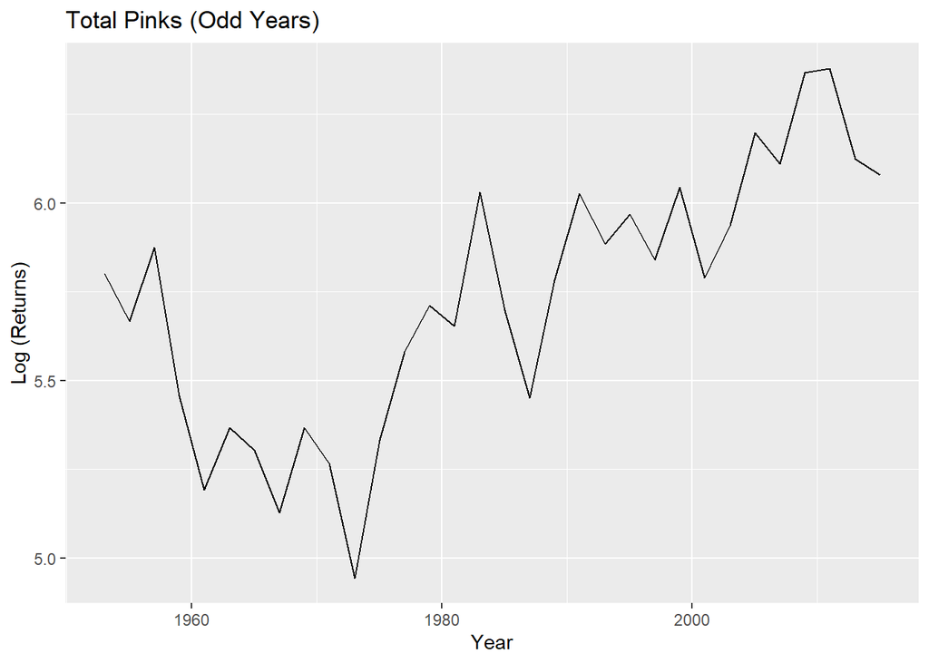

```r
PinkByRegion_odd %>%
  group_by(year) %>%
  summarize(total = sum(total, na.rm=T)) %>%
  ggplot(aes(x=year, y=log(total))) +
  geom_line() +
  ylab('Log (Returns)') +
  xlab('Year') +
  ggtitle('Total Pinks (Odd Years)')
```

Let’s look at the ACF and PACF for even years:

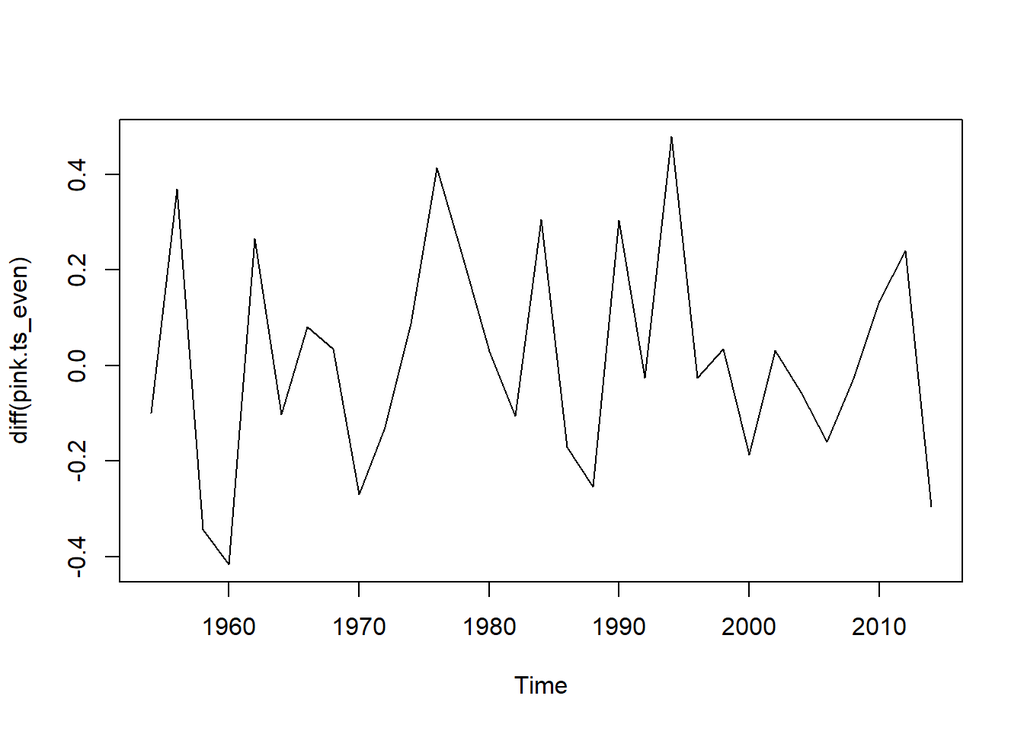

```r
#Even Years -- Total
total.pink_even<-PinkByRegion_even %>%
  group_by(year) %>%
  summarize(lntotal=log(sum(total, na.rm=T)))

pink.ts_even<-ts(total.pink_even$lntotal,
            start=total.pink$year[1], frequency = 0.5)
plot(diff(pink.ts_even)) #Looks pretty stationary
```

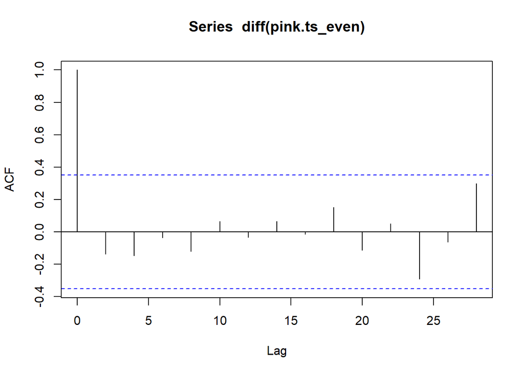

```r
acf(diff(pink.ts_even)) #This looks much better
```

The differences and the ACF plots here look better than the aggregate data set. Let’s look at a forcast.

```r
#Train and test for a 10 year period
train.pink_even<-window(pink.ts_even, start=1952, end=2004)
test.pink_even<-window(pink.ts_even, start=2006, end=2014)

fit <- forecast::auto.arima(train.pink_even, trace=T)
```

```
##
##  ARIMA(2,1,2) with drift         : Inf
##  ARIMA(0,1,0) with drift         : 2.346942
##  ARIMA(1,1,0) with drift         : 4.419114
##  ARIMA(0,1,1) with drift         : 4.222938
##  ARIMA(0,1,0)                    : 0.1554815
##  ARIMA(1,1,1) with drift         : Inf
##
##  Best model: ARIMA(0,1,0)
```

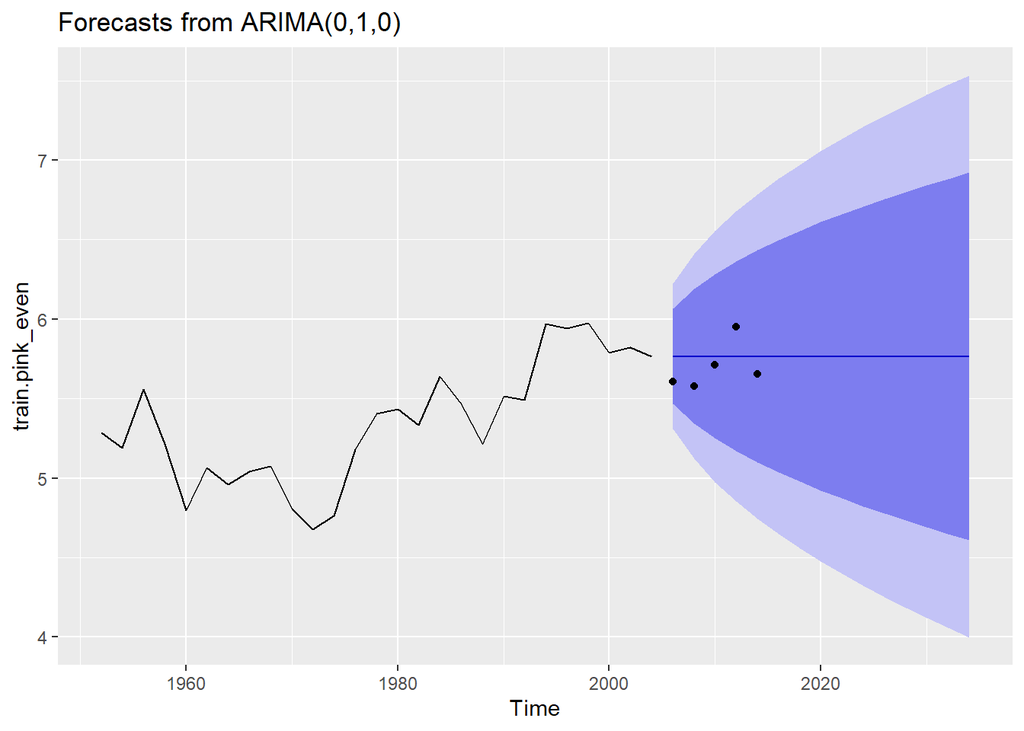

```r
fit.final.pink_even<-forecast::auto.arima(train.pink_even, approximation = F, stepwise = F)

fit.final.pink_even %>%
  forecast(h=15) %>%
  autoplot() + geom_point(aes(x=x, y=y), data=fortify(test.pink_even))
```

```r
#That is a straight line..... not very good.....
```

The best model was the ARIMA(0,1,0) model. But the forcast doesn’t capture the trend.

Let’s repeat the next steps for odd years.

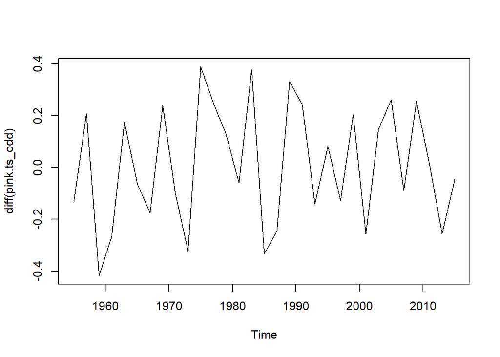

```r
#Odd Years -- Total

total.pink_odd<-PinkByRegion_odd %>%
  group_by(year) %>%
  summarize(lntotal=log(sum(total, na.rm=T)))

pink.ts_odd<-ts(total.pink_odd$lntotal,
                 start=total.pink_odd$year[1], frequency = 0.5)
plot(diff(pink.ts_odd)) #Looks pretty stationary
```

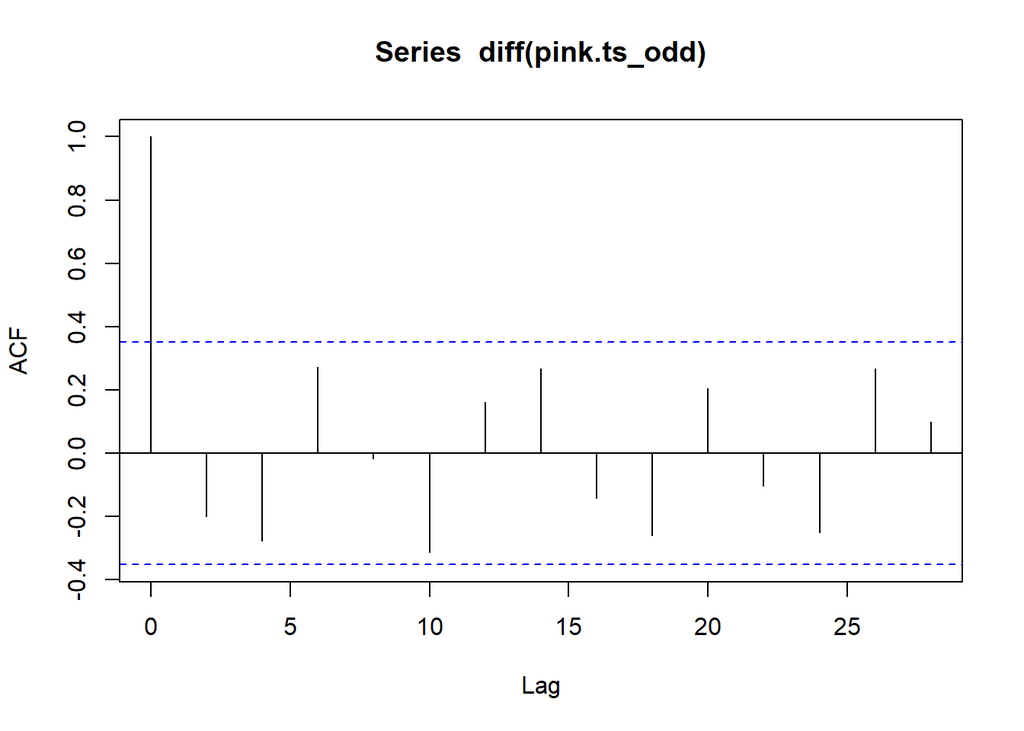

```r
acf(diff(pink.ts_odd)) #This also looks better
```

These look stationary and the ACF looks better.

```r
#Train and test for a 10 year period
train.pink_odd<-window(pink.ts_odd, start=1953, end=2005)
test.pink_odd<-window(pink.ts_odd, start=2007, end=2015)

fit <- forecast::auto.arima(train.pink_odd, trace=T)
```

```
##
##  ARIMA(2,1,2) with drift         : Inf
##  ARIMA(0,1,0) with drift         : 4.01998
##  ARIMA(1,1,0) with drift         : 5.551776
##  ARIMA(0,1,1) with drift         : 4.461601
##  ARIMA(0,1,0)                    : 1.771054
##  ARIMA(1,1,1) with drift         : Inf
##
##  Best model: ARIMA(0,1,0)
```

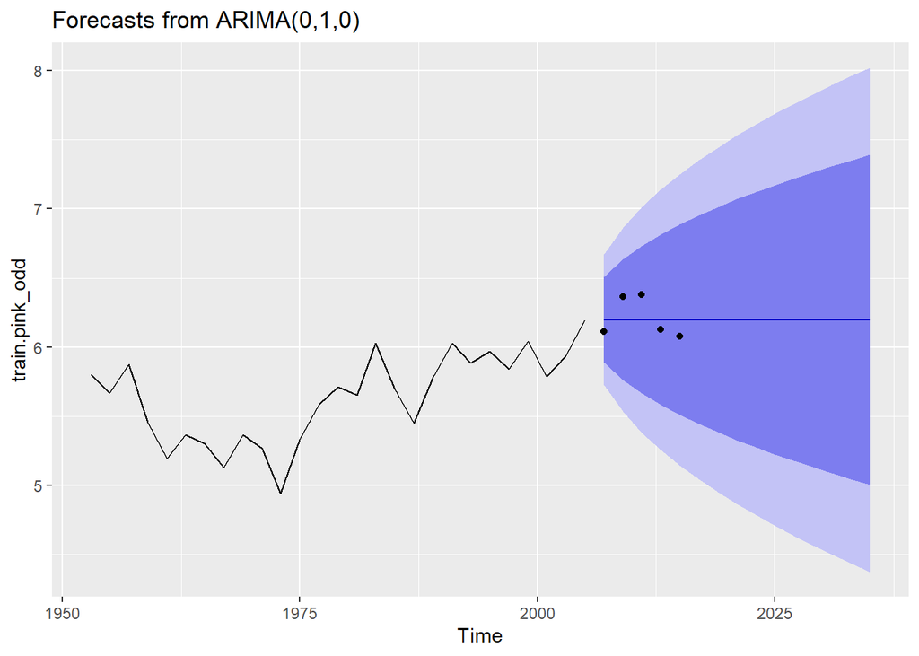

```r
fit.final.pink_odd<-forecast::auto.arima(train.pink_odd, approximation = F, stepwise = F)

fit.final.pink_odd %>%
  forecast(h=15) %>%
  autoplot() + geom_point(aes(x=x, y=y), data=fortify(test.pink_odd))
```

The best model was the ARIMA(0,1,0) model. But the forcast for only odd years also doesn’t capture the trend.

# Pinks: Regional Considerations

Because of pink salmon life history, for regional models, models with even and odd years were considered separately.

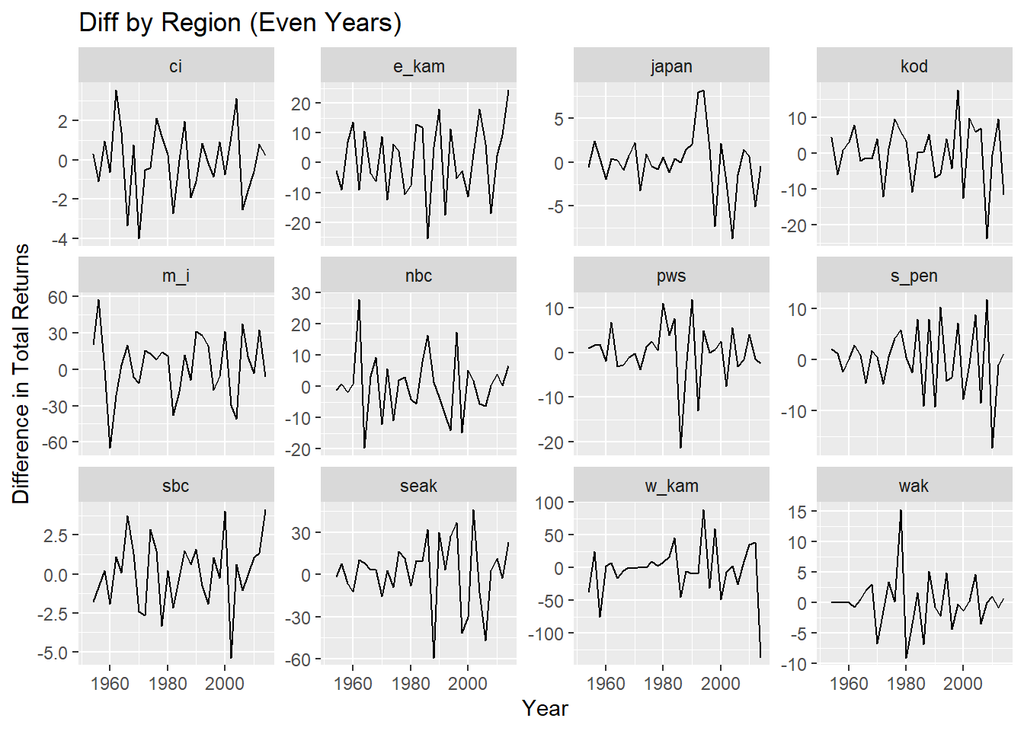

```r
#Even Years First
#Differenced plots for all Regions
PinkByRegion_even %>%
  group_by(region) %>%
  mutate(diff_total = c(NA, diff(total))) %>%
  ggplot(aes(x = year, y = diff_total)) +
  geom_line() +
  facet_wrap(~region, scales = "free_y") +
  ylab("Difference in Total Returns") +
  xlab("Year") +
  ggtitle("Diff by Region (Even Years)")
```

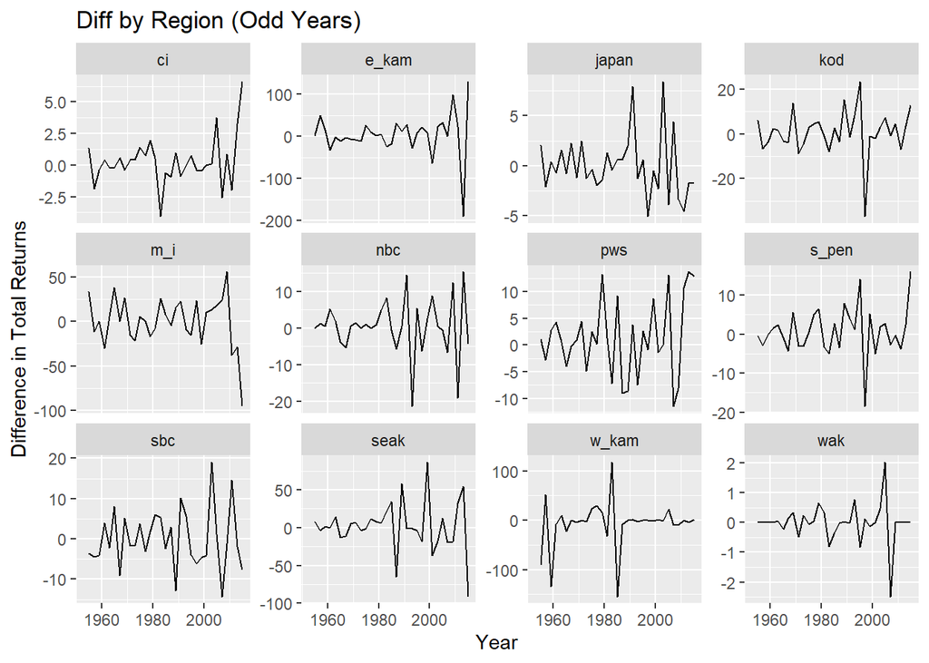

```r
  #ggfortify::ggstat_acf(method = "ma", na.action = na.pass)

# Odd Years First
#Differenced plots for all Regions
PinkByRegion_odd %>%
  group_by(region) %>%
  mutate(diff_total = c(NA, diff(total))) %>%
  ggplot(aes(x = year, y = diff_total)) +
  geom_line() +
  facet_wrap(~region, scales = "free_y") +
  ylab("Difference in Total Returns") +
  xlab("Year") +
  ggtitle("Diff by Region (Odd Years)")
```

To test stationarity outside the auto.arima function , the ADF and KPSS tests were compared for all years, and even and odd years. Note for the ADF null hypothesis is that the system is non-stationary (we want to reject), and the KPSS test null hypothesis is that there is stationarity.

```r
#Augmented Dicky Fuller
tseries::adf.test(pink.ts, k=0)
```

```
##
##  Augmented Dickey-Fuller Test
##
## data:  pink.ts
## Dickey-Fuller = -6.7912, Lag order = 0, p-value = 0.01
## alternative hypothesis: stationary
```

```r
tseries::adf.test(pink.ts_even, k=0)
```

```
##
##  Augmented Dickey-Fuller Test
##
## data:  pink.ts_even
## Dickey-Fuller = -2.7882, Lag order = 0, p-value = 0.2688
## alternative hypothesis: stationary
```

```r
tseries::adf.test(pink.ts_odd, k=0)
```

```
##
##  Augmented Dickey-Fuller Test
##
## data:  pink.ts_odd
## Dickey-Fuller = -3.3957, Lag order = 0, p-value = 0.07573
## alternative hypothesis: stationary
```

```r
tseries::kpss.test(pink.ts, null = c("Level", "Trend"))
```

```
##
##  KPSS Test for Level Stationarity
##
## data:  pink.ts
## KPSS Level = 1.2192, Truncation lag parameter = 3, p-value = 0.01
```

```r
tseries::kpss.test(pink.ts_even, null = c("Level", "Trend"))
```

```
##
##  KPSS Test for Level Stationarity
##
## data:  pink.ts_even
## KPSS Level = 0.64625, Truncation lag parameter = 3, p-value = 0.01843
```

```r
tseries::kpss.test(pink.ts_odd, null = c("Level", "Trend"))
```

```
##
##  KPSS Test for Level Stationarity
##
## data:  pink.ts_odd
## KPSS Level = 0.64278, Truncation lag parameter = 3, p-value = 0.01875
```

A complication is that the data sets split by even and odd years were not passing the tests of stationarity. Perhaps other steps should have been taken.

```r
#Functions for Regional ACF and PACF
#======================================================
ACFandPACF<-function(reg){
  Pinkdat<-PinkByRegion %>% filter(region == reg)
  #create time series
  datts <- ts(Pinkdat$lnreturns, start=Pinkdat$year[1])
  return(list(a = acf(datts, plot = FALSE), p = pacf(datts, plot = FALSE)))
}

ACFandPACF_even<-function(reg){
  Pinkdat<-PinkByRegion_even %>% filter(region == reg)
  #create time series
  datts <- ts(Pinkdat$lnreturns, start=Pinkdat$year[1])
  return(list(a = acf(datts, plot = FALSE), p = pacf(datts, plot = FALSE)))
}

ACFandPACF_odd<-function(reg){
  Pinkdat<-PinkByRegion_odd %>% filter(region == reg)
  #create time series
  datts <- ts(Pinkdat$lnreturns, start=Pinkdat$year[1])
  return(list(a = acf(datts, plot = FALSE), p = pacf(datts, plot = FALSE)))
}

FitModFunction<-function(reg, forelevel){
  #filter region
  Pinkdat<-PinkByRegion %>% filter(region == reg)
  #create time series
  datts <- ts(Pinkdat$lnreturns, start=Pinkdat$year[1], frequency = 0.5) #set Frequency for 0.5
  cutoff<-2014-forelevel
  train <- window(datts, Pinkdat$year[1], cutoff)
  test <- window(datts, cutoff+1, 2014)

  mod <- auto.arima(train)
  #testing to be sure that this is the best model (is the best mode the simplest if it is within 2 AIC values?)
  trace <- capture.output({
    # assign so it doesn't pollute the output
    model <- auto.arima(datts, trace = TRUE)
  })
  con    <- textConnection(trace)
  models <- read.table(con, sep=":")
  close(con)

  #getting the "best models" that are within 2 AIC units
  BestMods<-models%>% filter(row_number() != nrow(models)) %>% mutate(AIC = replace(V2, V2 == "Inf", 99999), AIC = as.numeric(AIC), DeltaAIC = AIC-min(AIC)) %>% filter(DeltaAIC <= 2.0)
  for(i in 1:nrow(BestMods)){
    BestMods$Mod[i]<-strsplit(strsplit(strsplit(BestMods$V1[i], "[(]")[[1]][2], "[)]")[[1]][1],"[,]")
    BestMods$npar[i]<-sum(as.numeric(BestMods$Mod[i][[1]][c(1,3)]))
    if(strsplit(strsplit(BestMods$V1[i], "[(]")[[1]][2], "[)]")[[1]][2] == " with drift         "){
      BestMods$npar[i] = BestMods$npar[i] + 1
    }
  }

  New<-BestMods %>% filter(npar == min(npar))
  if(0 %in% New$DeltaAIC){
    #auto arima picked the best model
    res<-accuracy(forecast(mod, h=forelevel), test)[2,"MASE"] #test set MASE
  }else{
    #of the models with the fewest parameters, pick the lowest AIC
    newmod<-New %>% filter(AIC == min(AIC)) %>% select(Mod)
    mod<-Arima(train, order = as.numeric(strsplit(newmod$Mod[[1]], "[,]")), include.constant = TRUE)
    res<-accuracy(forecast(mod, h=forelevel), test)[2,"MASE"] #test set MASE
  }

  return(list(Fit = mod, MASE = res, Bm = BestMods)) #include best mods for testing to see that it's doing what I want

}

FitModFunction_even<-function(reg, forelevel){
  #filter region
  Pinkdat<-PinkByRegion_even %>% filter(region == reg)
  #create time series
  datts <- ts(Pinkdat$lnreturns, start=Pinkdat$year[1], frequency = 0.5) #set Frequency for 0.5
  cutoff<-2014-forelevel
  train <- window(datts, Pinkdat$year[1], cutoff)
  test <- window(datts, cutoff+1, 2014)

  mod <- auto.arima(train)
  #testing to be sure that this is the best model (is the best mode the simplest if it is within 2 AIC values?)
  trace <- capture.output({
    # assign so it doesn't pollute the output
    model <- auto.arima(datts, trace = TRUE)
  })
  con    <- textConnection(trace)
  models <- read.table(con, sep=":")
  close(con)

  #getting the "best models" that are within 2 AIC units
  BestMods<-models%>% filter(row_number() != nrow(models)) %>% mutate(AIC = replace(V2, V2 == "Inf", 99999), AIC = as.numeric(AIC), DeltaAIC = AIC-min(AIC)) %>% filter(DeltaAIC <= 2.0)
  for(i in 1:nrow(BestMods)){
    BestMods$Mod[i]<-strsplit(strsplit(strsplit(BestMods$V1[i], "[(]")[[1]][2], "[)]")[[1]][1],"[,]")
    BestMods$npar[i]<-sum(as.numeric(BestMods$Mod[i][[1]][c(1,3)]))
    if(strsplit(strsplit(BestMods$V1[i], "[(]")[[1]][2], "[)]")[[1]][2] == " with drift         "){
      BestMods$npar[i] = BestMods$npar[i] + 1
    }
  }

  New<-BestMods %>% filter(npar == min(npar))
  if(0 %in% New$DeltaAIC){
    #auto arima picked the best model
    res<-accuracy(forecast(mod, h=forelevel), test)[2,"MASE"] #test set MASE
  }else{
    #of the models with the fewest parameters, pick the lowest AIC
    newmod<-New %>% filter(AIC == min(AIC)) %>% select(Mod)
    mod<-Arima(train, order = as.numeric(strsplit(newmod$Mod[[1]], "[,]")), include.constant = TRUE)
    res<-accuracy(forecast(mod, h=forelevel), test)[2,"MASE"] #test set MASE
  }

  return(list(Fit = mod, MASE = res, Bm = BestMods)) #include best mods for testing to see that it's doing what I want

}

FitModFunction_odd<-function(reg, forelevel){
  #filter region
  Pinkdat<-PinkByRegion_odd %>% filter(region == reg)
  #create time series
  datts <- ts(Pinkdat$lnreturns, start=Pinkdat$year[1], frequency = 0.5)
  cutoff<-2015-forelevel
  train <- window(datts, Pinkdat$year[1], cutoff)
  test <- window(datts, cutoff+1, 2015)

  mod <- auto.arima(train)
  #testing to be sure that this is the best model (is the best mode the simplest if it is within 2 AIC values?)
  trace <- capture.output({
    # assign so it doesn't pollute the output
    model <- auto.arima(datts, trace = TRUE)
  })
  con    <- textConnection(trace)
  models <- read.table(con, sep=":")
  close(con)

  #getting the "best models" that are within 2 AIC units
  BestMods<-models%>% filter(row_number() != nrow(models)) %>% mutate(AIC = replace(V2, V2 == "Inf", 99999), AIC = as.numeric(AIC), DeltaAIC = AIC-min(AIC)) %>% filter(DeltaAIC <= 2.0)
  for(i in 1:nrow(BestMods)){
    BestMods$Mod[i]<-strsplit(strsplit(strsplit(BestMods$V1[i], "[(]")[[1]][2], "[)]")[[1]][1],"[,]")
    BestMods$npar[i]<-sum(as.numeric(BestMods$Mod[i][[1]][c(1,3)]))
    if(strsplit(strsplit(BestMods$V1[i], "[(]")[[1]][2], "[)]")[[1]][2] == " with drift         "){
      BestMods$npar[i] = BestMods$npar[i] + 1
    }
  }

  New<-BestMods %>% filter(npar == min(npar))
  if(0 %in% New$DeltaAIC){
    #auto arima picked the best model
    res<-accuracy(forecast(mod, h=forelevel), test)[2,"MASE"] #test set MASE
  }else{
    #of the models with the fewest parameters, pick the lowest AIC
    newmod<-New %>% filter(AIC == min(AIC)) %>% select(Mod)
    mod<-Arima(train, order = as.numeric(strsplit(newmod$Mod[[1]], "[,]")), include.constant = TRUE)
    res<-accuracy(forecast(mod, h=forelevel), test)[2,"MASE"] #test set MASE
  }

  return(list(Fit = mod, MASE = res, Bm = BestMods)) #include best mods for testing to see that it's doing what I want

}

#================================================================
```

Next step is to then define the regions

```r
#regions vector
regions<-unique(PinkByRegion$region)
#regions key
regionskey<-c("Cook Inlet", "E. Kamchatka", "Japan", "Kodiak", "Russia", "N.British Columbia",
              "Prince William Sound", "S. Alaska Pen.", "S. British Columbia", "SE Alaska", "W. Kamchatka", "W. Alaska")
names(regionskey)<-regions #for plotting

#loop through regions/levels
#all
DiagPlots<-lapply(regions, ACFandPACF)
   names(DiagPlots)<-regions

#Even
DiagPlots_even<-lapply(regions, ACFandPACF_even)
   names(DiagPlots_even)<-regions

#Odd
DiagPlots_odd<-lapply(regions, ACFandPACF_odd)
   names(DiagPlots_odd)<-regions
```

Lets look at the regional breakdowns of ACF and PACF, first for all years:

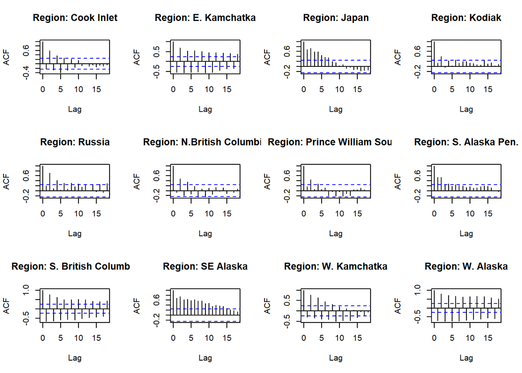

```r
#Even Years
par(mfrow=c(3,4))
for(r in 1:length(regions)){
  plot(DiagPlots[[r]][[1]], main = paste0("Region: ", regionskey[r]))
}
```

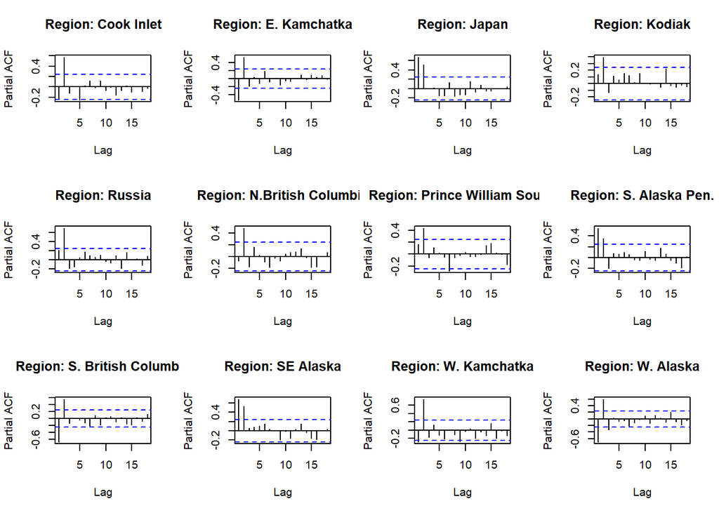

```r
#PACF plots for each region
par(mfrow=c(3,4))
for(r in 1:length(regions)){
  plot(DiagPlots[[r]][[2]], main = paste0("Region: ", regionskey[r]))
}
```

The ACFs for regions show different levels of lag or total correlation. Let’s look for even years:

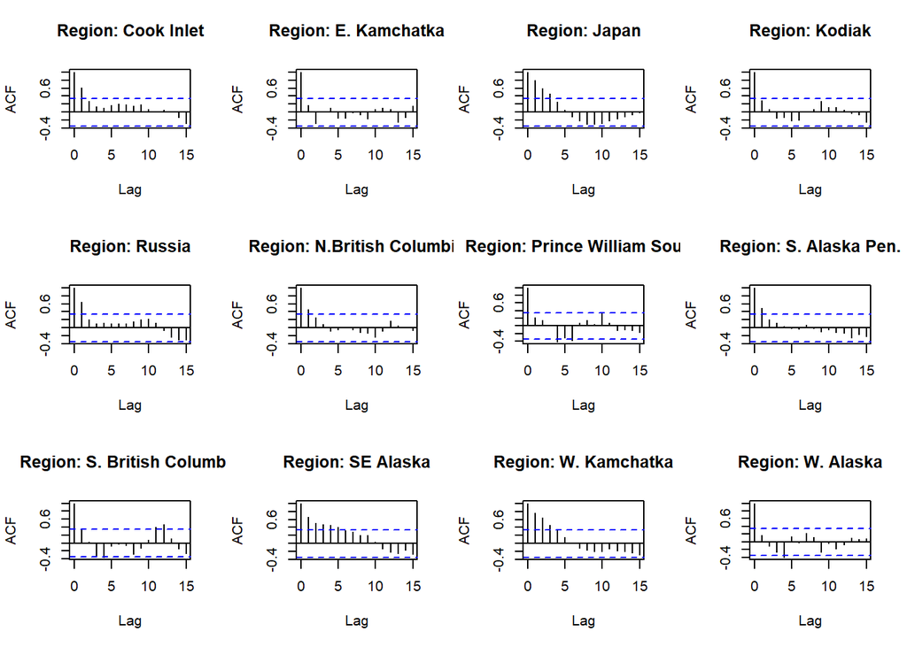

```r
#Even Years
par(mfrow=c(3,4))
for(r in 1:length(regions)){
  plot(DiagPlots_even[[r]][[1]], main = paste0("Region: ", regionskey[r]))
}
```

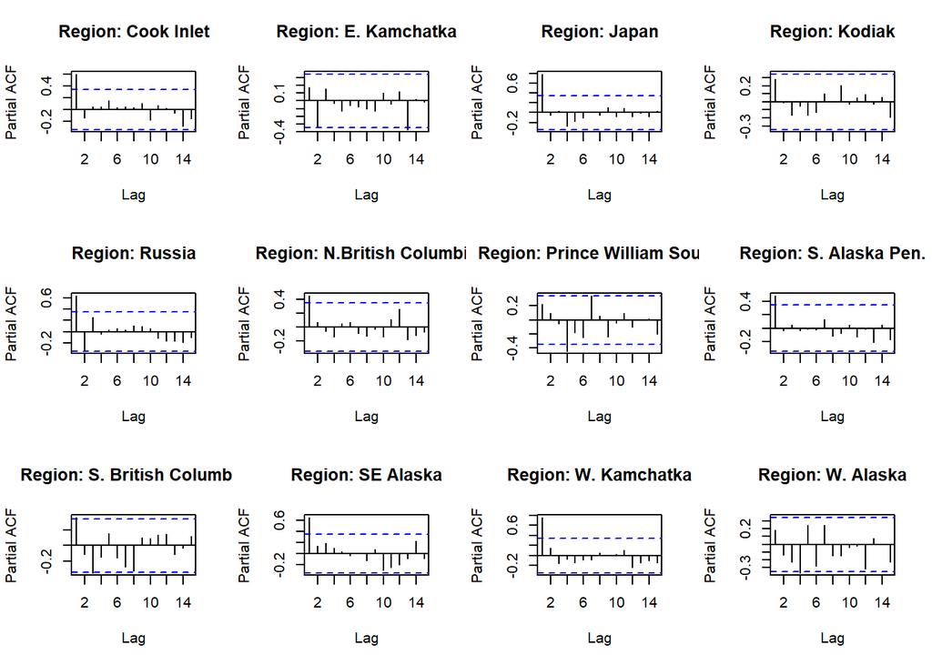

```r
#PACF plots for each region
par(mfrow=c(3,4))
for(r in 1:length(regions)){
  plot(DiagPlots_even[[r]][[2]], main = paste0("Region: ", regionskey[r]))
}
```

And then for odd years:

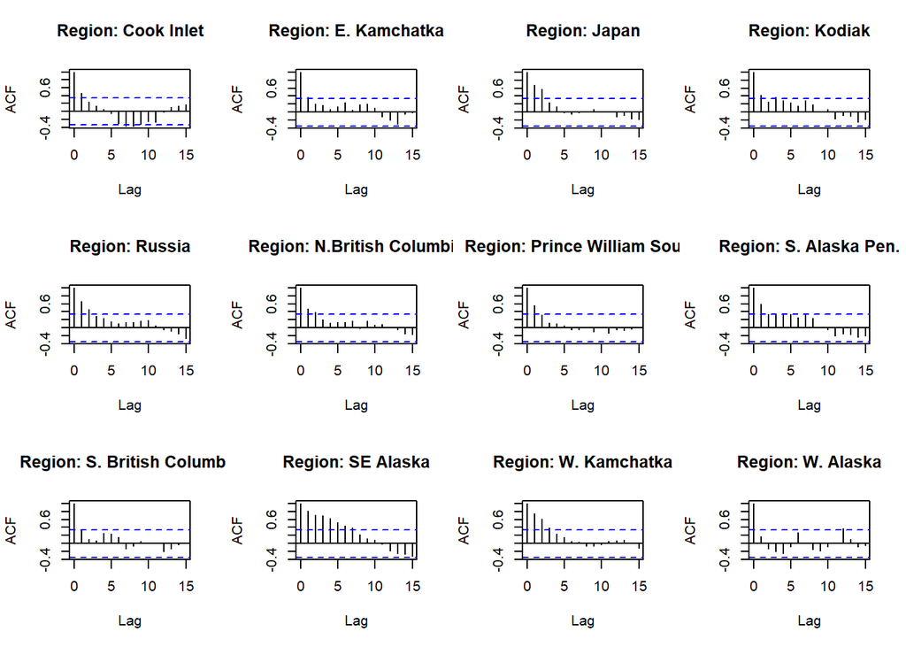

```r
#Odd Years
par(mfrow=c(3,4))
for(r in 1:length(regions)){
  plot(DiagPlots_odd[[r]][[1]], main = paste0("Region: ", regionskey[r]))
}
```